# Estimating the Effects of Encumbrance and Walking on Mixed Reality Interaction

Supplementary Material

Author

Tinghui Li, Eduardo Velloso, Anusha Withana, Zhanna Sarsenbayeva

Published

February 3, 2025

# 1 Introduction

This code contains the process, models, figures, and results that were used to analyze the effects of encumbrance and walking on movement time (see section 3.1), pointing offset (see section 3.2), error rate (see section 3.3), target acquisition throughput (see section 3.4), text entry throughput (see section 4.1), uncorrected error rate/corrected error rate (section 4.2), and words per minute (section 4.3) with Bayesian regression models. We plot the results for visual representation and report the posterior probability to further prove our model as well.

# 2 Library

The key libraries used for model generation and plotting, along with their respective versions, are listed below.

```r
cat("lme4:", as.character(packageVersion("lme4")),
    "glmmTMB:", as.character(packageVersion("glmmTMB")),
    "brms:", as.character(packageVersion("brms")),
    "betareg:", as.character(packageVersion("betareg")),
    "bayestestR:", as.character(packageVersion("bayestestR")),
    "ggplot2:", as.character(packageVersion("ggplot2")))
```

```
lme4: 1.1.35.5 glmmTMB: 1.1.10 brms: 2.22.0 betareg: 3.2.1 bayestestR: 0.15.0 ggplot2: 3.5.1
```

# 3 Target Acquisition Task

This section contains the analysis of target acquisition task performed in the paper.

**3.1 Movement Time**

**Direct Selection**

Model for target acquisition (direct selection)

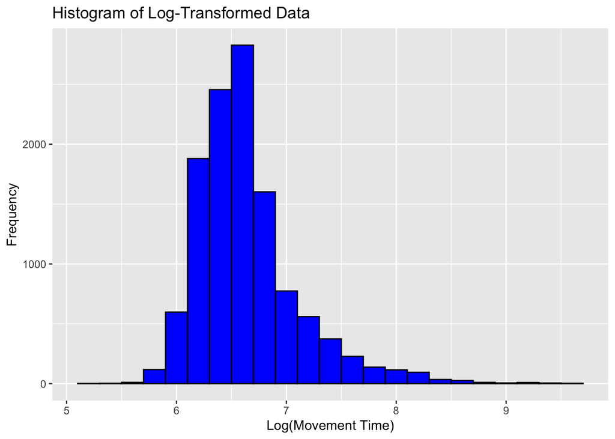

```r
ggplot(mt_poke, aes(x = log(MT))) +
  geom_histogram(binwidth = 0.2, color = "black", fill = "blue") +
  labs(title = "Histogram of Log-Transformed Data", x = "Log(Movement Time)", y = "Frequency")
```

```r
mt_model_poke <- brm(MT ~ 1 + (1|participant) + iterationNum + exercise + (ID * (weight * movement)),
                mt_poke,
                family = shifted_lognormal(),
                iter = 4000,
                save_pars = save_pars(all = TRUE))
saveRDS(mt_model, file = "brm_model/mt_model_poke.rds")
```

```r
mt_model_poke <- readRDS("brm_model/mt_model_poke.rds")
summary(mt_model_poke)
```

```
 Family: shifted_lognormal
  Links: mu = identity; sigma = identity; ndt = identity
Formula: MT ~ 1 + (1 | participant) + iterationNum + exercise + (ID * (weight * movement))
   Data: no_error_poke (Number of observations: 11877)
  Draws: 4 chains, each with iter = 4000; warmup = 2000; thin = 1;
         total post-warmup draws = 8000

Multilevel Hyperparameters:
~participant (Number of levels: 30)
              Estimate Est.Error l-95% CI u-95% CI Rhat Bulk_ESS Tail_ESS
sd(Intercept)     0.31      0.04     0.24     0.40 1.00     1196     2043

Regression Coefficients:
                          Estimate Est.Error l-95% CI u-95% CI Rhat Bulk_ESS
Intercept                     6.06      0.09     5.87     6.25 1.00     1234
iterationNum                 -0.05      0.00    -0.06    -0.05 1.00     6569
exercise                     -0.01      0.01    -0.03     0.00 1.00     1512
ID                            0.28      0.04     0.20     0.36 1.00     2542
weight                        0.41      0.05     0.31     0.51 1.00     2520
movementWalking               0.17      0.05     0.08     0.27 1.00     2355
weight:movementWalking       -0.07      0.07    -0.21     0.07 1.00     2425
ID:weight                    -0.11      0.06    -0.24     0.02 1.00     2396
ID:movementWalking            0.07      0.06    -0.05     0.19 1.00     2220
ID:weight:movementWalking     0.14      0.09    -0.04     0.31 1.00     2326
                          Tail_ESS
Intercept                     1956
iterationNum                  4829
exercise                      1908
ID                            3563
weight                        3709
movementWalking               3541
weight:movementWalking        3152
ID:weight                     3430
ID:movementWalking            3674
ID:weight:movementWalking     3349

Further Distributional Parameters:
      Estimate Est.Error l-95% CI u-95% CI Rhat Bulk_ESS Tail_ESS
sigma     0.46      0.00     0.45     0.46 1.00     5754     5189
ndt     177.66      0.77   176.00   179.02 1.00     5358     4967

Draws were sampled using sampling(NUTS). For each parameter, Bulk_ESS
and Tail_ESS are effective sample size measures, and Rhat is the potential
scale reduction factor on split chains (at convergence, Rhat = 1).
```

**Ray-Casting**

Model for target acquisition (ray-casting)

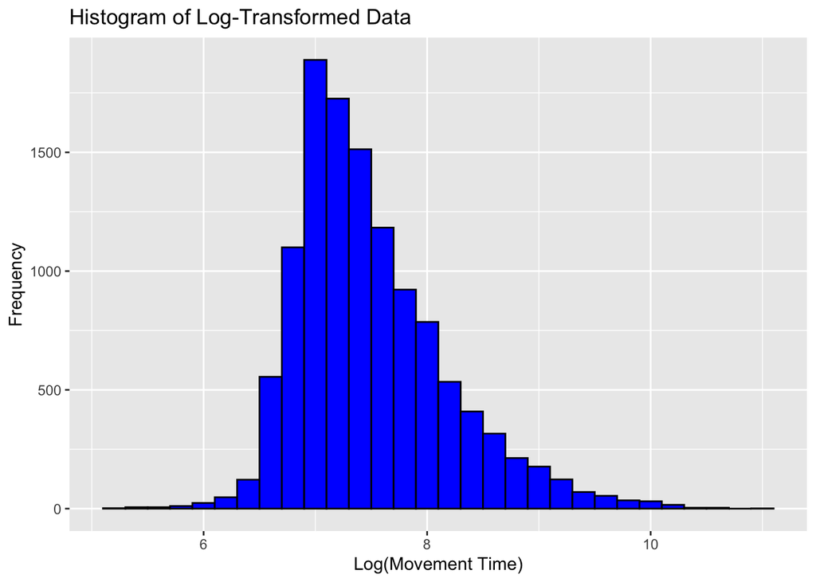

```r
ggplot(mt_ray, aes(x = log(MT))) +
  geom_histogram(binwidth = 0.2, color = "black", fill = "blue") +
  labs(title = "Histogram of Log-Transformed Data", x = "Log(Movement Time)", y = "Frequency")
```

```r
mt_model_ray <- brm(MT ~ 1 + (1|participant) + iterationNum + exercise + (ID * (weight * movement)),
                mt_ray,
                family = shifted_lognormal(),
                iter = 4000,
                save_pars = save_pars(all = TRUE))
saveRDS(mt_model, file = "brm_model/mt_model_ray.rds")
```

```r
mt_model_ray <- readRDS("brm_model/mt_model_ray.rds")
summary(mt_model_ray)
```

[output not shown]

**Validation**

Posterior Probability Check

```
Using 10 posterior draws for ppc type 'dens_overlay' by default.
```

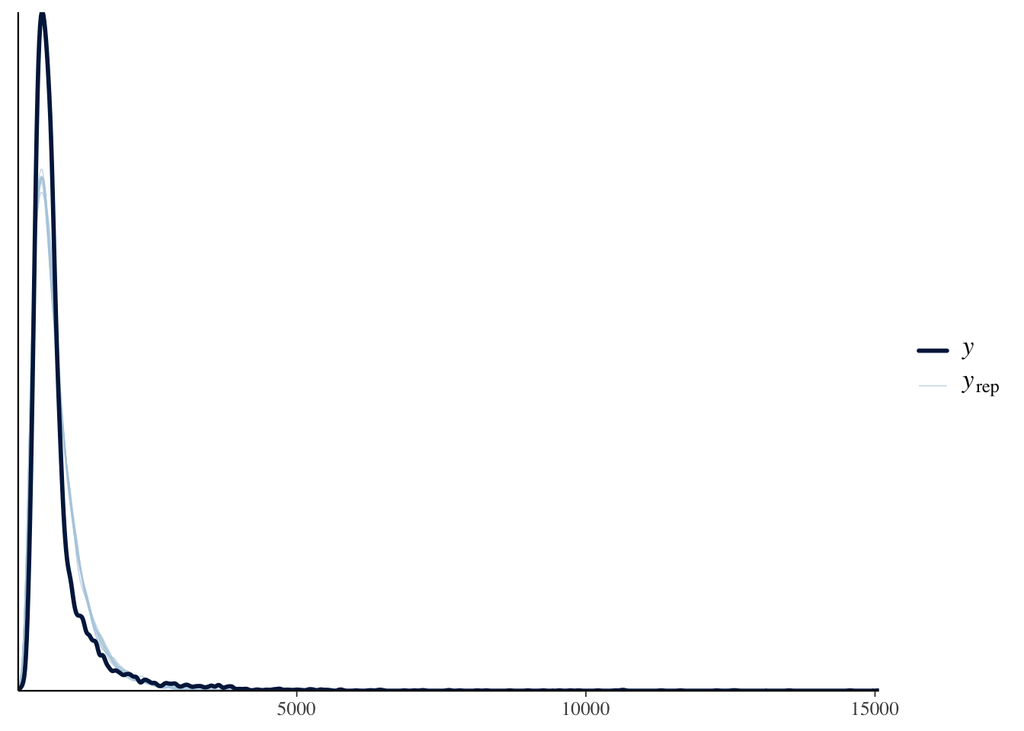

```r
# Target Acquisition (Direct Selection) Movement Time Model
pp_check(mt_model_poke)
```

```r
# Target Acquisition (Direct Selection) Movement Time Model
post <- as_draws_df(mt_model_poke)
cat("Weight Probability:", as.character(mean(post$b_weight > 0)),
    "Motion Probability:", as.character(mean(post$b_movementWalking > 0)),
    "Weight x Motion Probability:", as.character(mean(post$`b_weight:movementWalking` > 0)))
```

```
Weight Probability: 1 Motion Probability: 1 Weight x Motion Probability: 0.186875
```

```
Using 10 posterior draws for ppc type 'dens_overlay' by default.
```

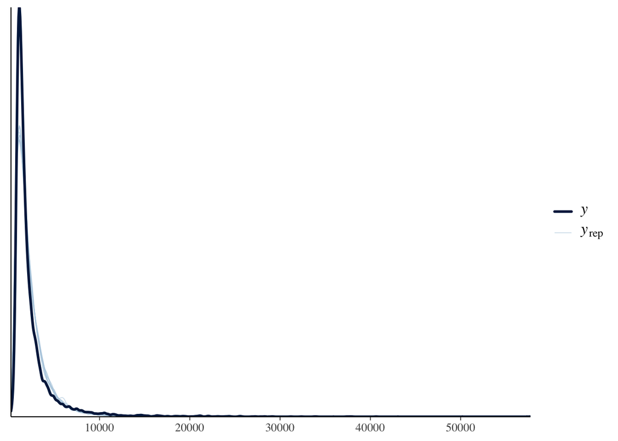

```r
# Target Acquisition (Ray-Casting) Movement Time Model
pp_check(mt_model_ray)
```

```r
# Target Acquisition (Ray-Casting) Movement Time Model
post <- as_draws_df(mt_model_ray)
cat("Weight Probability:", as.character(mean(post$b_weight > 0)),
    "Motion Probability:", as.character(mean(post$b_movementWalking > 0)),
    "Weight x Motion Probability:", as.character(mean(post$`b_weight:movementWalking` > 0)))
```

```
Weight Probability: 1 Motion Probability: 0.929 Weight x Motion Probability: 0.986
```

Bayes Factor

```r
# Target Acquisition (Direct Selection) Movement Time without Weight
mt_model_poke_weight <- brm(MT ~ 1 + (1|participant) + iterationNum + exercise + (ID * movement),
                               data = mt_poke,
                               family = shifted_lognormal(),
                               iter = 4000,
                               save_pars = save_pars(all = TRUE))
saveRDS(mt_model_poke_weight, file = "brm_model/mt_model_poke_weight.rds")

# Target Acquisition (Direct Selection) Movement Time without Motion
mt_model_poke_movement <- brm(MT ~ 1 + (1|participant) + iterationNum + exercise + (ID * weight),
                               data = mt_poke,
                               family = shifted_lognormal(),
                               iter = 4000,
                               save_pars = save_pars(all = TRUE))
saveRDS(mt_model_poke_movement, file = "brm_model/mt_model_poke_movement.rds")

# Target Acquisition (Ray-Casting) Movement Time without Weight
mt_model_ray_weight <- brm(MT ~ 1 + (1|participant) + (1|order) + exercise + (ID * movement),
                mt_ray,
                family = shifted_lognormal(),
                iter = 5000,
                save_pars = save_pars(all = TRUE))
saveRDS(mt_model_ray_weight, file = "brm_model/mt_model_ray_weight.rds")

# Target Acquisition (Ray-Casting) Movement Time without Motion
mt_model_ray_movement <- brm(MT ~ 1 + (1|participant) + iterationNum + exercise + (ID * weight),
                mt_ray,
                family = shifted_lognormal(),
                iter = 5000,
                save_pars = save_pars(all = TRUE))
saveRDS(mt_model_ray_movement, file = "brm_model/mt_model_ray_movement.rds")
```

```r
mt_model_poke_weight <- readRDS("brm_model/mt_model_poke_weight.rds")
mt_model_poke_movement <- readRDS("brm_model/mt_model_poke_movement.rds")
mt_model_ray_weight <- readRDS("brm_model/mt_model_ray_weight.rds")
mt_model_ray_movement <- readRDS("brm_model/mt_model_ray_movement.rds")

bf_mt_poke_weight <- bayes_factor(mt_model_poke, mt_model_poke_weight)
bf_mt_poke_movement <- bayes_factor(mt_model_poke, mt_model_poke_movement)
bf_mt_ray_weight <- bayes_factor(mt_model_ray, mt_model_ray_weight)
bf_mt_ray_movement <- bayes_factor(mt_model_ray, mt_model_ray_movement)
```

```r
# Target Acquisition (Direct Selection) Movement Time without Weight
print(bf_mt_poke_weight)
```

[output not shown]

```r
# Target Acquisition (Direct Selection) Movement Time without Motion
print(bf_mt_poke_movement)
```

```
Estimated Bayes factor in favor of mt_model_poke over mt_model_poke_movement: 45967948027229486546461942633664313557225991762044189197933929938417523452508722244621818754054815040951576832711421876441522343187255757843385028279273071797346437015580344057856.00000
```

```r
# Target Acquisition (Ray-Casting) Movement Time without Weight
print(bf_mt_ray_weight)
```

```
Estimated Bayes factor in favor of mt_model_ray over mt_model_ray_weight: 141699340824287369083892770663921232630760317557146210391409070187606806806564448501760.00000
```

```r
# Target Acquisition (Ray-Casting) Movement Time without Motion
print(bf_mt_ray_movement)
```

```
Estimated Bayes factor in favor of mt_model_ray over mt_model_ray_movement:    Inf
```

**Plot**

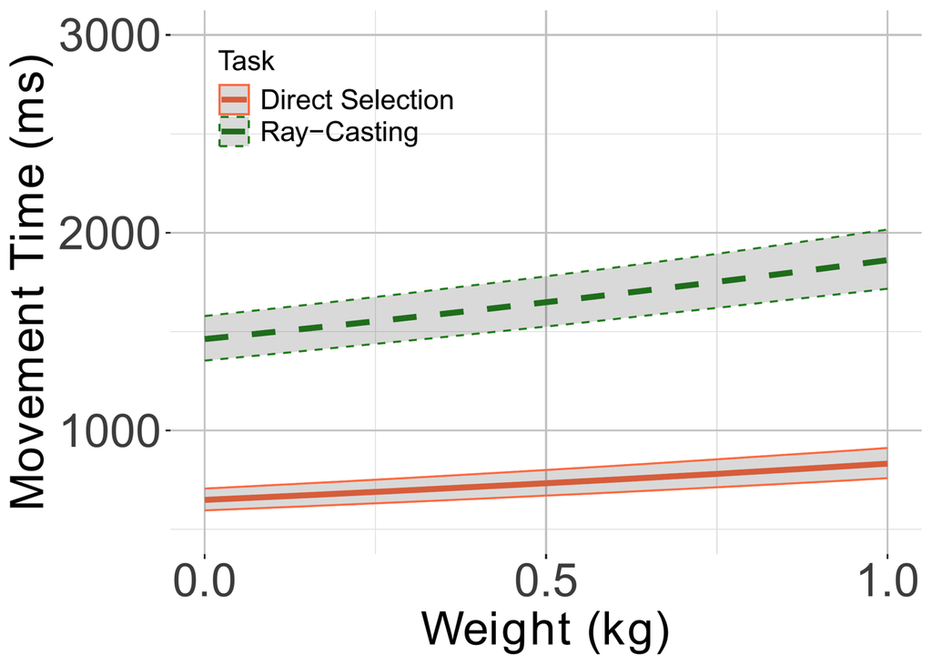

```r
# Effect of Weight on Movement Time
combined_weight_plot
```

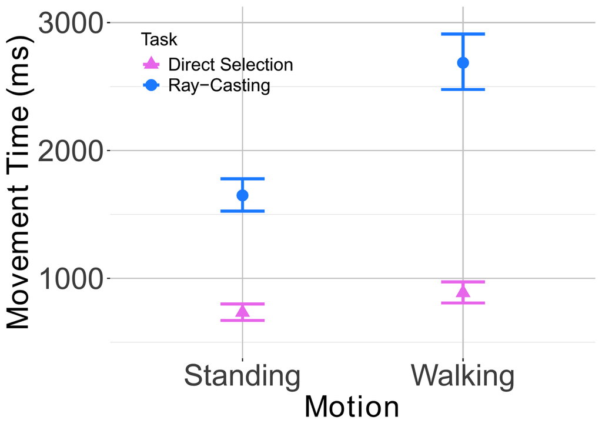

```r
# Effect of Motion on Movement Time
combined_motion_plot
```

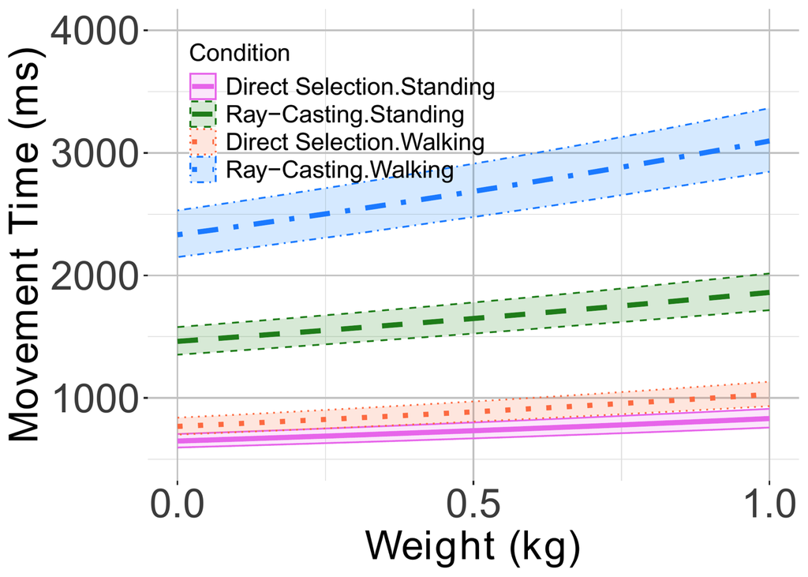

```r
# Interaction Effect of Weight and Motion on Movement Time
combined_interaction_plot
```

**3.2 Pointing Offset**

This section presents the pointing offset models and the corresponding outcomes from the target acquisition task.

**Direct Selection**

Model for target acquisition (direct selection)

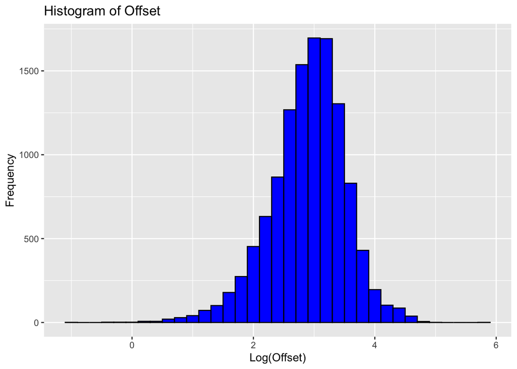

```r
ggplot(offset_poke, aes(x = log(offset))) +
  geom_histogram(binwidth = 0.2, color = "black", fill = "blue") +
  labs(title = "Histogram of Offset", x = "Log(Offset)", y = "Frequency")
```

```r
offset_model_poke <- brm(
  formula = offset ~ 1 + (1 | participant) + iterationNum + exercise + width * (weight * movement),
  data = offset_poke,
  family = shifted_lognormal(),
  iter = 4000,
  save_pars = save_pars(all = TRUE)
)
saveRDS(offset_model_poke, file = "brm_model/offset_model_poke.rds")
```

```r
offset_model_poke <- readRDS("brm_model/offset_model_poke.rds")
summary(offset_model_poke)
```

```
 Family: shifted_lognormal
  Links: mu = identity; sigma = identity; ndt = identity
Formula: offset ~ 1 + (1 | participant) + iterationNum + exercise + width * (weight * movement)
   Data: no_error_poke (Number of observations: 11877)
  Draws: 4 chains, each with iter = 4000; warmup = 2000; thin = 1;
         total post-warmup draws = 8000

Multilevel Hyperparameters:
~participant (Number of levels: 30)
              Estimate Est.Error l-95% CI u-95% CI Rhat Bulk_ESS Tail_ESS
sd(Intercept)     0.11      0.02     0.08     0.14 1.00     1310     2615

Regression Coefficients:
                             Estimate Est.Error l-95% CI u-95% CI Rhat Bulk_ESS
Intercept                        2.43      0.06     2.31     2.54 1.00     1701
iterationNum                     0.01      0.00     0.00     0.02 1.00    10533
exercise                         0.01      0.00    -0.00     0.01 1.00     1123
width                            0.01      0.00     0.00     0.01 1.00     2984
weight                          -0.25      0.07    -0.39    -0.11 1.00     2577
movementWalking                  0.04      0.06    -0.09     0.17 1.00     2548
weight:movementWalking           0.11      0.10    -0.09     0.31 1.00     2131
width:weight                     0.00      0.00     0.00     0.00 1.00     2529
width:movementWalking            0.00      0.00    -0.00     0.00 1.00     2572
width:weight:movementWalking    -0.00      0.00    -0.00     0.00 1.00     2184
                             Tail_ESS
Intercept                        3206
iterationNum                     5816
exercise                         1776
width                            4884
weight                           4206
movementWalking                  4210
weight:movementWalking           3668
width:weight                     4329
width:movementWalking            4492
width:weight:movementWalking     3957

Further Distributional Parameters:
      Estimate Est.Error l-95% CI u-95% CI Rhat Bulk_ESS Tail_ESS
sigma     0.59      0.00     0.59     0.60 1.00     8608     5868
ndt       0.00      0.00     0.00     0.02 1.00     5778     3271

Draws were sampled using sampling(NUTS). For each parameter, Bulk_ESS
and Tail_ESS are effective sample size measures, and Rhat is the potential
scale reduction factor on split chains (at convergence, Rhat = 1).
```

**Ray-Casting**

Model for target acquisition (ray-casting)

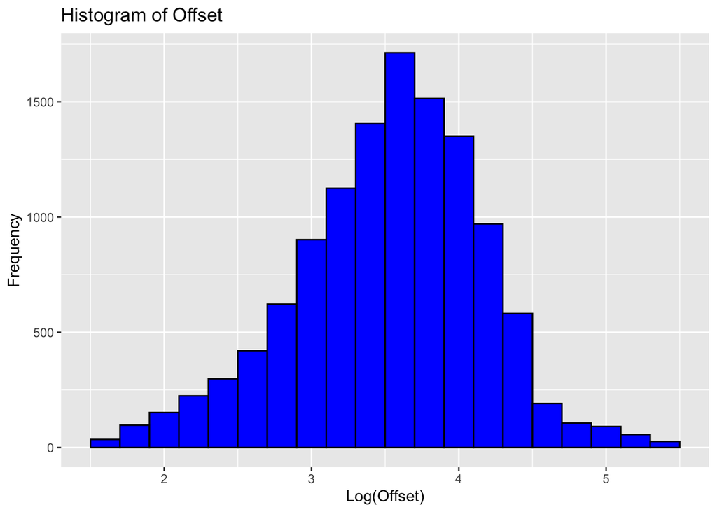

```r
ggplot(offset_ray, aes(x = log(offset))) +
  geom_histogram(binwidth = 0.2, color = "black", fill = "blue") +
  labs(title = "Histogram of Offset", x = "Log(Offset)", y = "Frequency")
```

```r
offset_model_ray <- brm(
  formula = offset ~ 1 + (1 | participant) + iterationNum + exercise + width * (weight * movement),
  data = offset_ray,
  family = shifted_lognormal(),
  save_pars = save_pars(all = TRUE)
)
saveRDS(offset_model_ray, file = "brm_model/offset_model_ray.rds")
```

```r
offset_model_ray <- readRDS("brm_model/offset_model_ray.rds")
summary(offset_model_ray)
```

```
 Family: shifted_lognormal
  Links: mu = identity; sigma = identity; ndt = identity
Formula: offset ~ 1 + (1 | participant) + iterationNum + exercise + width * (weight * movement)
   Data: no_error_ray (Number of observations: 11880)
  Draws: 4 chains, each with iter = 2000; warmup = 1000; thin = 1;
         total post-warmup draws = 4000

Multilevel Hyperparameters:
~participant (Number of levels: 30)
              Estimate Est.Error l-95% CI u-95% CI Rhat Bulk_ESS Tail_ESS
sd(Intercept)     0.04      0.01     0.02     0.06 1.00     1203     1669

Regression Coefficients:
                             Estimate Est.Error l-95% CI u-95% CI Rhat Bulk_ESS
Intercept                        2.69      0.05     2.60     2.79 1.00     2854
iterationNum                     0.00      0.00    -0.00     0.01 1.00     5824
exercise                         0.00      0.00    -0.00     0.00 1.00     2409
width                            0.01      0.00     0.01     0.01 1.00     3040
weight                          -0.00      0.07    -0.14     0.13 1.00     2995
movementWalking                  0.12      0.06    -0.01     0.24 1.00     2692
weight:movementWalking          -0.04      0.10    -0.23     0.16 1.00     2500
width:weight                     0.00      0.00    -0.00     0.00 1.00     2967
width:movementWalking            0.00      0.00    -0.00     0.00 1.00     2708
width:weight:movementWalking     0.00      0.00    -0.00     0.00 1.00     2509
                             Tail_ESS
Intercept                        3284
iterationNum                     2676
exercise                         2431
width                            3288
weight                           3109
movementWalking                  2924
weight:movementWalking           2815
width:weight                     3057
width:movementWalking            3277
width:weight:movementWalking     2993

Further Distributional Parameters:
      Estimate Est.Error l-95% CI u-95% CI Rhat Bulk_ESS Tail_ESS
sigma     0.59      0.00     0.58     0.60 1.00     4791     3189
ndt       0.02      0.02     0.00     0.07 1.00     3056     1747

Draws were sampled using sampling(NUTS). For each parameter, Bulk_ESS
and Tail_ESS are effective sample size measures, and Rhat is the potential
scale reduction factor on split chains (at convergence, Rhat = 1).
```

**Validation**

Posterior Probability Check

```
Using 10 posterior draws for ppc type 'dens_overlay' by default.
```

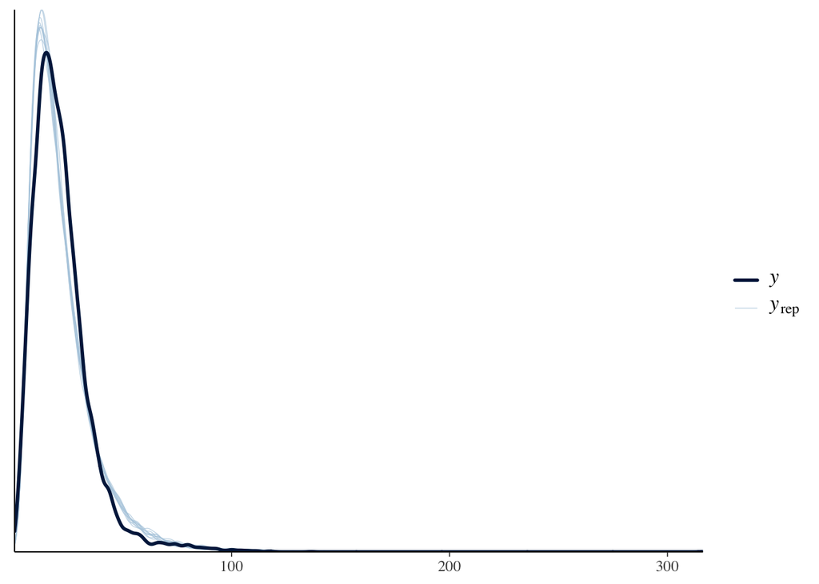

```r
# Target Acquisition (Direct Selection) Offset Model
pp_check(offset_model_poke)
```

```r
# Target Acquisition (Direct Selection) Offset Model
post <- as_draws_df(offset_model_poke)
cat("Weight Probability:", as.character(mean(post$b_weight > 0)),
    "Motion Probability:", as.character(mean(post$b_movementWalking > 0)),
    "Weight x Motion Probability:", as.character(mean(post$`b_weight:movementWalking` > 0)))
```

```
Weight Probability: 0.00025 Motion Probability: 0.742875 Weight x Motion Probability: 0.860375
```

```
Using 10 posterior draws for ppc type 'dens_overlay' by default.
```

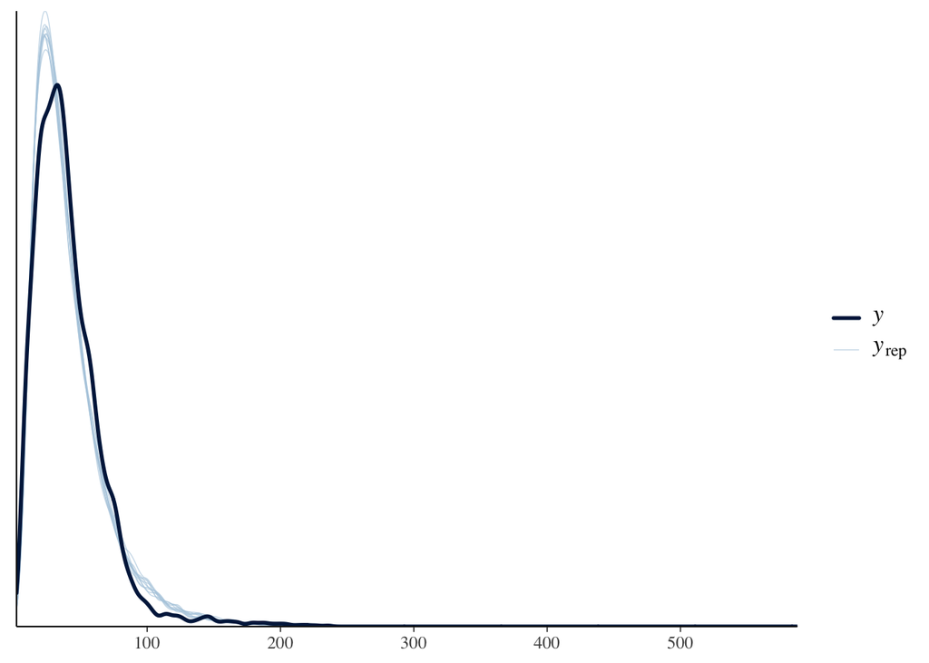

```r
# Target Acquisition (Ray-Casting) Offset Model
pp_check(offset_model_ray)
```

```r
# Target Acquisition (Ray-Casting) Offset Model
post <- as_draws_df(offset_model_ray)
cat("Weight Probability:", as.character(mean(post$b_weight > 0)),
    "Motion Probability:", as.character(mean(post$b_movementWalking > 0)),
    "Weight x Motion Probability:", as.character(mean(post$`b_weight:movementWalking` > 0)))
```

```
Weight Probability: 0.49425 Motion Probability: 0.964 Weight x Motion Probability: 0.367
```

Bayes Factor

```r
# Target Acquisition (Direct Selection) Offset without Weight
offset_model_poke_weight <- brm(offset ~ 1 + (1 | participant) + iterationNum + exercise + width * movement,
                             offset_poke,
                             family = shifted_lognormal(),
                             iter = 4000,
                             save_pars = save_pars(all = TRUE))
saveRDS(offset_model_poke_weight, file = "brm_model/offset_model_poke_weight.rds")

# Target Acquisition (Direct Selection) Offset without Motion
offset_model_poke_movement <- brm(offset ~ 1 + (1 | participant) + (1|order) + exercise + width * weight,
                               offset_poke,
                               family = shifted_lognormal(),
                               iter = 4000,
                               save_pars = save_pars(all = TRUE))
saveRDS(offset_model_poke_movement, file = "brm_model/offset_model_poke_movement.rds")

# Target Acquisition (Ray-Casting) Offset without Weight
offset_model_ray_weight <- brm(offset ~ 1 + (1 | participant) + iterationNum + exercise + width * movement,
                     offset_ray,
                     family = shifted_lognormal(),
                     save_pars = save_pars(all = TRUE))
saveRDS(offset_model_ray_weight, file = "brm_model/offset_model_ray_weight.rds")

# Target Acquisition (Ray-Casting) Offset without Motion
offset_model_ray_movement <- brm(offset ~ 1 + (1 | participant) + iterationNum + exercise + width * weight,
                     offset_ray,
                     family = shifted_lognormal(),
                     save_pars = save_pars(all = TRUE))
saveRDS(offset_model_ray_movement, file = "brm_model/offset_model_ray_movement.rds")
```

```r
offset_model_poke_weight <- readRDS("brm_model/offset_model_poke_weight.rds")
offset_model_poke_movement <- readRDS("brm_model/offset_model_poke_movement.rds")
offset_model_ray_weight <- readRDS("brm_model/offset_model_ray_weight.rds")
offset_model_ray_movement <- readRDS("brm_model/offset_model_ray_movement.rds")

bf_offset_poke_weight <- bayes_factor(offset_model_poke, offset_model_poke_weight)
bf_offset_poke_movement <- bayes_factor(offset_model_poke, offset_model_poke_movement)
bf_offset_ray_weight <- bayes_factor(offset_model_ray, offset_model_ray_weight)
bf_offset_ray_movement <- bayes_factor(offset_model_ray, offset_model_ray_movement)
```

```r
# Target Acquisition (Direct Selection) Offset without Weight
print(bf_offset_poke_weight)
```

```
Estimated Bayes factor in favor of offset_model_poke over offset_model_poke_weight: 1.44394
```

```r
# Target Acquisition (Direct Selection) Offset without Motion
print(bf_offset_poke_movement)
```

```
Estimated Bayes factor in favor of offset_model_poke over offset_model_poke_movement: 1960939006892845481530129666539520.00000
```

```r
# Target Acquisition (Ray-Casting) Offset without Weight
print(bf_offset_ray_weight)
```

```
Estimated Bayes factor in favor of offset_model_ray over offset_model_ray_weight: 0.00000
```

```r
# Target Acquisition (Ray-Casting) Offset without Motion
print(bf_offset_ray_movement)
```

```
Estimated Bayes factor in favor of offset_model_ray over offset_model_ray_movement: 284699629050047409548931400877809336320.00000
```

**Plot**

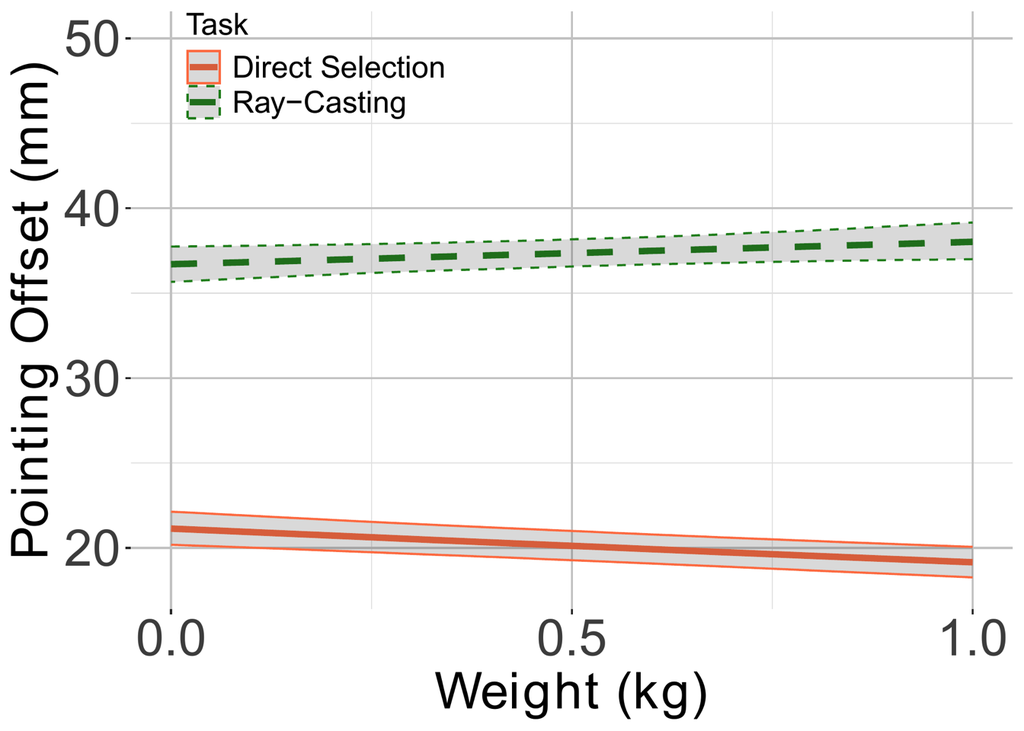

```r
# Effect of Weight on Offset
combined_weight_plot
```

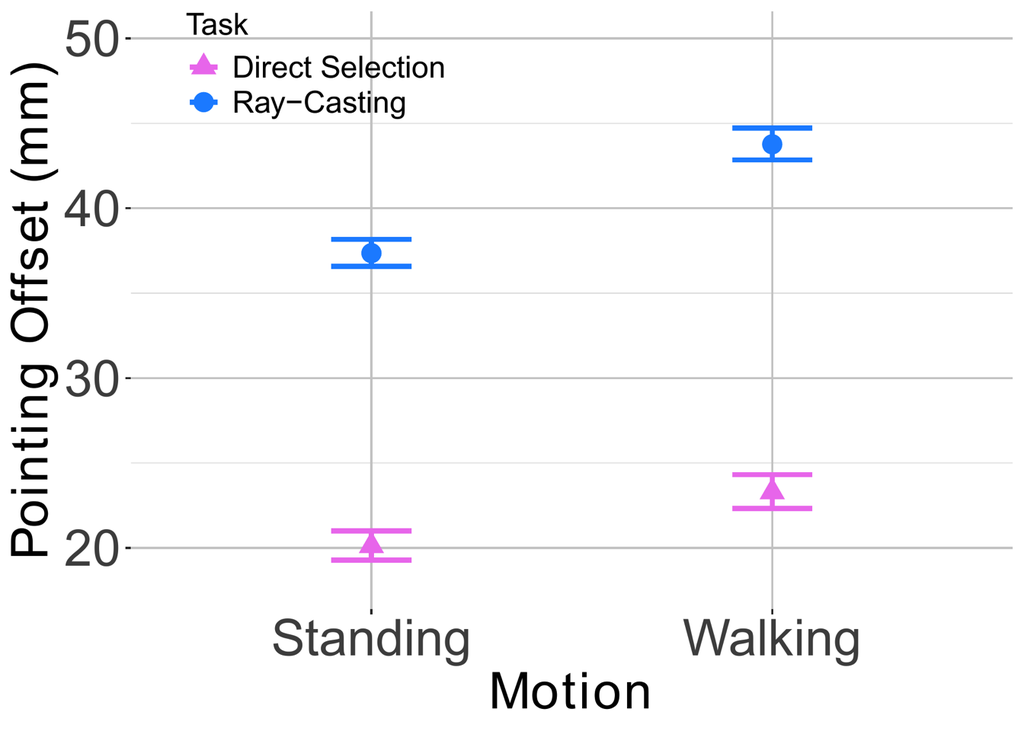

```r
# Effect of Motion on Offset
combined_motion_plot
```

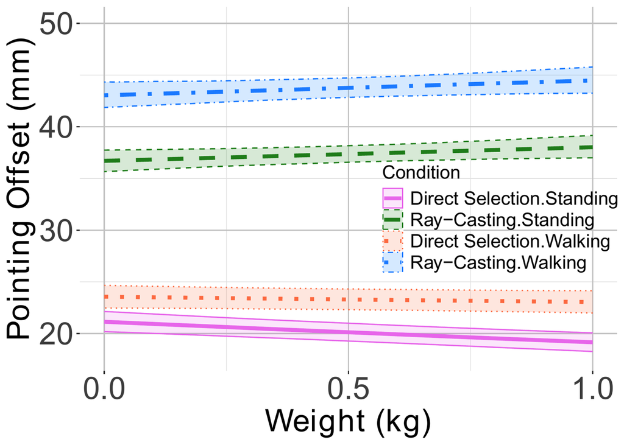

```r
# Interaction Effect of Weight and Motion on Offsets
combined_interaction_plot
```

**3.3 Error Rate**

This section presents the error rate models and the corresponding outcomes from the target acquisition task.

**Direct Selection**

Model for target acquisition (direct selection)

```r
err_model_poke <- brm(error ~ 1 + (1|participant) + iterationNum + exercise + (ID * (weight * movement)),
                      poke,
                      family = poisson(),
                      save_pars = save_pars(all = TRUE))
saveRDS(err_model_poke, file = "brm_model/err_model_poke.rds")
```

```r
err_model_poke <- readRDS("brm_model/err_model_poke.rds")
summary(err_model_poke)
```

```
 Family: poisson
  Links: mu = log
Formula: error ~ 1 + (1 | participant) + iterationNum + exercise + (ID * (weight * movement))
   Data: poke (Number of observations: 11978)
  Draws: 4 chains, each with iter = 2000; warmup = 1000; thin = 1;
         total post-warmup draws = 4000

Multilevel Hyperparameters:
~participant (Number of levels: 30)
              Estimate Est.Error l-95% CI u-95% CI Rhat Bulk_ESS Tail_ESS
sd(Intercept)     0.78      0.21     0.44     1.25 1.00     1429     2327

Regression Coefficients:
                          Estimate Est.Error l-95% CI u-95% CI Rhat Bulk_ESS
Intercept                    -5.90      0.94    -7.77    -4.09 1.00     1573
iterationNum                  0.05      0.06    -0.07     0.17 1.00     6047
exercise                      0.03      0.03    -0.02     0.08 1.00     2403
ID                            0.36      1.08    -1.82     2.41 1.00     1494
weight                        1.02      1.36    -1.64     3.70 1.00     1262
movementWalking               1.93      1.22    -0.45     4.39 1.00     1242
weight:movementWalking       -1.87      1.80    -5.39     1.67 1.00     1164
ID:weight                    -1.57      1.77    -5.12     1.94 1.00     1343
ID:movementWalking           -2.69      1.62    -5.93     0.44 1.00     1318
ID:weight:movementWalking     3.73      2.39    -1.06     8.43 1.00     1224
                          Tail_ESS
Intercept                     2382
iterationNum                  2878
exercise                      2624
ID                            2176
weight                        2204
movementWalking               2104
weight:movementWalking        1822
ID:weight                     2191
ID:movementWalking            2034
ID:weight:movementWalking     1790

Draws were sampled using sampling(NUTS). For each parameter, Bulk_ESS
and Tail_ESS are effective sample size measures, and Rhat is the potential
scale reduction factor on split chains (at convergence, Rhat = 1).
```

**Ray-Casting**

Model for target acquisition (ray-casting)

```r
err_model_ray <- brm(error ~ 1 + (1|participant) + iterationNum + exercise + (ID * (weight * movement)),
                     ray,
                     family = poisson(),
                     iter = 3000,
                     save_pars = save_pars(all = TRUE))
saveRDS(err_model_ray, file = "brm_model/err_model_ray.rds")
```

```r
err_model_ray <- readRDS("brm_model/err_model_ray.rds")
summary(err_model_ray)
```

```
 Family: poisson
  Links: mu = log
Formula: error ~ 1 + (1 | participant) + iterationNum + exercise + (ID * (weight * movement))
   Data: ray (Number of observations: 12908)
  Draws: 4 chains, each with iter = 3000; warmup = 1500; thin = 1;
         total post-warmup draws = 6000

Multilevel Hyperparameters:
~participant (Number of levels: 30)
              Estimate Est.Error l-95% CI u-95% CI Rhat Bulk_ESS Tail_ESS
sd(Intercept)     0.71      0.11     0.53     0.96 1.00     1247     2282

Regression Coefficients:
                          Estimate Est.Error l-95% CI u-95% CI Rhat Bulk_ESS
Intercept                    -4.01      0.59    -5.15    -2.87 1.00     1492
iterationNum                  0.04      0.02    -0.00     0.08 1.00     4775
exercise                     -0.01      0.02    -0.04     0.03 1.00     1160
ID                           -0.59      0.71    -2.02     0.75 1.00     1430
weight                       -0.65      0.81    -2.23     0.91 1.00     1359
movementWalking               2.05      0.59     0.92     3.20 1.00     1438
weight:movementWalking        0.58      0.86    -1.09     2.30 1.00     1348
ID:weight                     1.21      1.02    -0.74     3.20 1.00     1318
ID:movementWalking           -0.11      0.76    -1.55     1.41 1.00     1450
ID:weight:movementWalking    -0.82      1.08    -2.97     1.23 1.00     1315
                          Tail_ESS
Intercept                     2451
iterationNum                  3922
exercise                      1891
ID                            2404
weight                        2332
movementWalking               2330
weight:movementWalking        2286
ID:weight                     2172
ID:movementWalking            2386
ID:weight:movementWalking     2109

Draws were sampled using sampling(NUTS). For each parameter, Bulk_ESS
and Tail_ESS are effective sample size measures, and Rhat is the potential
scale reduction factor on split chains (at convergence, Rhat = 1).
```

**Validation**

Posterior Probability Check

```
Using 10 posterior draws for ppc type 'dens_overlay' by default.
```

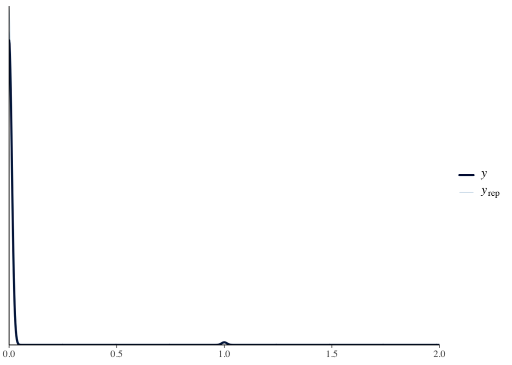

```r
# Target Acquisition (Direct Selection) Error Rate Model
pp_check(err_model_poke)
```

```r
# Target Acquisition (Direct Selection) Error Rate Model
post <- as_draws_df(err_model_poke)
cat("Weight Probability:", as.character(mean(post$b_weight > 0)),
    "Motion Probability:", as.character(mean(post$b_movementWalking > 0)),
    "Weight x Motion Probability:", as.character(mean(post$`b_weight:movementWalking` > 0)))
```

```
Weight Probability: 0.77 Motion Probability: 0.9455 Weight x Motion Probability: 0.1455
```

```
Using 10 posterior draws for ppc type 'dens_overlay' by default.
```

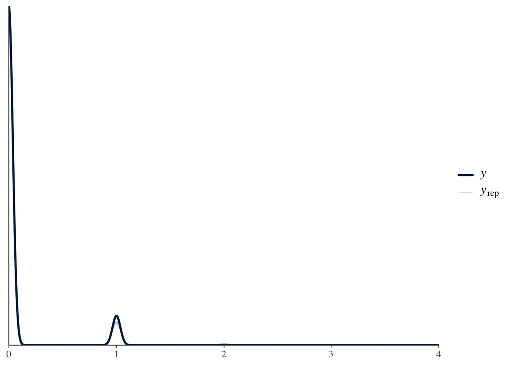

```r
# Target Acquisition (Ray-Casting) Error Rate Model
pp_check(err_model_ray)
```

```r
# Target Acquisition (Ray-Casting) Error Rate Model
post <- as_draws_df(err_model_ray)
cat("Weight Probability:", as.character(mean(post$b_weight > 0)),
    "Motion Probability:", as.character(mean(post$b_movementWalking > 0)),
    "Weight x Motion Probability:", as.character(mean(post$`b_weight:movementWalking` > 0)))
```

```
Weight Probability: 0.217 Motion Probability: 0.999833333333333 Weight x Motion Probability: 0.745833333333333
```

Bayes Factor

```r
# Target Acquisition (Direct Selection) Error Rate without Weight
err_model_poke_weight <- brm(error ~ 1 + (1|participant) + iterationNum + exercise + (ID * movement), poke, family = poisson(), save_pars = save_pars(all = TRUE))
saveRDS(err_model_poke_weight, file = "brm_model/err_model_poke_weight.rds")

# Target Acquisition (Direct Selection) Error Rate without Motion
err_model_poke_movement <- brm(error ~ 1 + (1|participant) + iterationNum + exercise + (ID * weight), poke, family = poisson(), save_pars = save_pars(all = TRUE))
saveRDS(err_model_poke_movement, file = "brm_model/err_model_poke_movement.rds")

# Target Acquisition (Ray-Casting) Error Rate without Weight
err_model_ray_weight <- brm(error ~ 1 + (1|participant) + iterationNum + exercise + (ID * movement), ray, family = poisson(), iter = 3000, save_pars = save_pars(all = TRUE))
saveRDS(err_model_ray_weight, file = "brm_model/err_model_ray_weight.rds")

# Target Acquisition (Ray-Casting) Error Rate without Motion
err_model_ray_movement <- brm(error ~ 1 + (1|participant) + iterationNum + exercise + (ID * weight), ray, family = poisson(), iter = 3000, save_pars = save_pars(all = TRUE))
saveRDS(err_model_ray_movement, file = "brm_model/err_model_ray_movement.rds")
```

```r
err_model_poke_weight <- readRDS("brm_model/err_model_poke_weight.rds")
err_model_poke_movement <- readRDS("brm_model/err_model_poke_movement.rds")
err_model_ray_weight <- readRDS("brm_model/err_model_ray_weight.rds")
err_model_ray_movement <- readRDS("brm_model/err_model_ray_movement.rds")

bf_err_poke_weight <- bayes_factor(err_model_poke, err_model_poke_weight)
bf_err_poke_movement <- bayes_factor(err_model_poke, err_model_poke_movement)
bf_err_ray_weight <- bayes_factor(err_model_ray, err_model_ray_weight)
bf_err_ray_movement <- bayes_factor(err_model_ray, err_model_ray_movement)
```

```r
# Target Acquisition (Direct Selection) Error Rate without Weight
print(bf_err_poke_weight)
```

```
Estimated Bayes factor in favor of err_model_poke over err_model_poke_weight: 504.45755
```

```r
# Target Acquisition (Direct Selection) Error Rate without Motion
print(bf_err_poke_movement)
```

```
Estimated Bayes factor in favor of err_model_poke over err_model_poke_movement: 1269.29526
```

```r
# Target Acquisition (Ray-Casting) Error Rate without Weight
print(bf_err_ray_weight)
```

```
Estimated Bayes factor in favor of err_model_ray over err_model_ray_weight: 83.28777
```

```r
# Target Acquisition (Ray-Casting) Error Rate without Motion
print(bf_err_ray_movement)
```

```
Estimated Bayes factor in favor of err_model_ray over err_model_ray_movement: 960303539253815798042592358768939348005679829458041452384837507437709113691942491964125531173486811208479513378073209565347840.00000
```

**Plot**

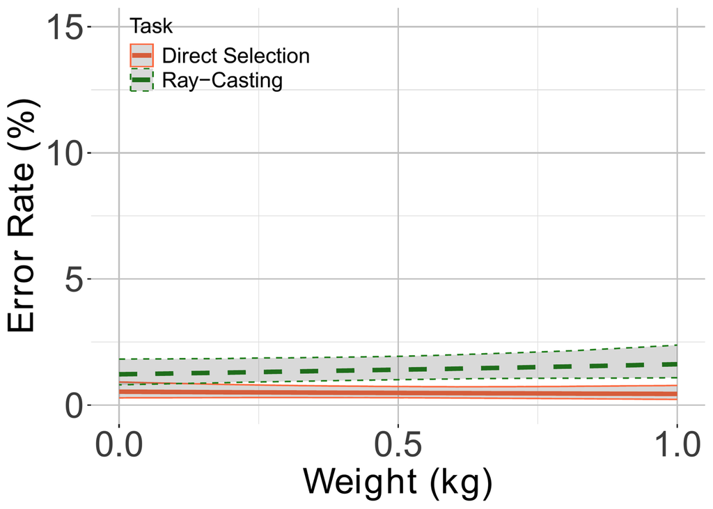

```r
# Effect of Weight on Error Rate
combined_weight_plot
```

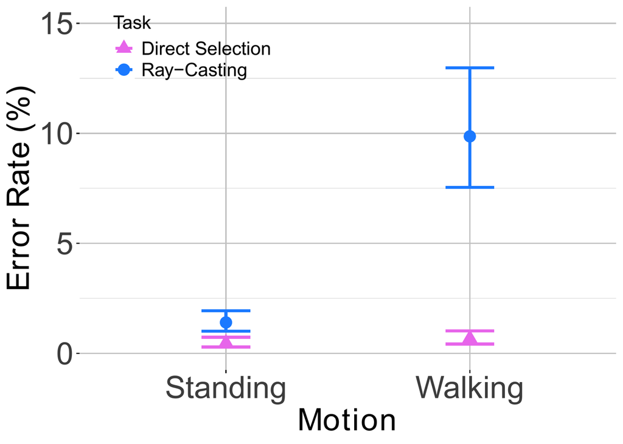

```r
# Effect of Motion on Error Rate
combined_motion_plot
```

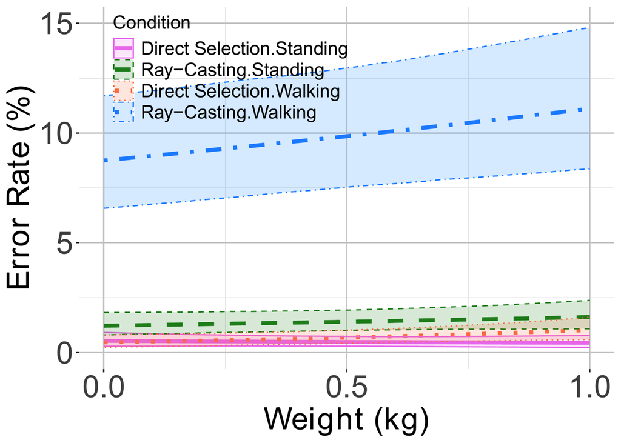

```r
# Interaction Effect of Weight and Motion on Error Rate
combined_interaction_plot
```

**3.4 Target Acquisition Throughput**

**Direct Selection**

Model for target acquisition (direct selection)

```r
tp_poke <- poke %>%
  # Step 1: Group by participant, width, distance, and iterationNum, calculate SD of accuracy
  group_by(participant, halfWidth, distance, iterationNum) %>%
  mutate(SD = sd(accuracy, na.rm = TRUE)) %>%
  ungroup() %>%

  # Step 2: Calculate ID_e
  mutate(We = 4.133 * SD,
         IDe = log2((distance / We) + 1)) %>%

  # Step 3: Calculate TP
  mutate(TP = IDe / (MT/1000))
```

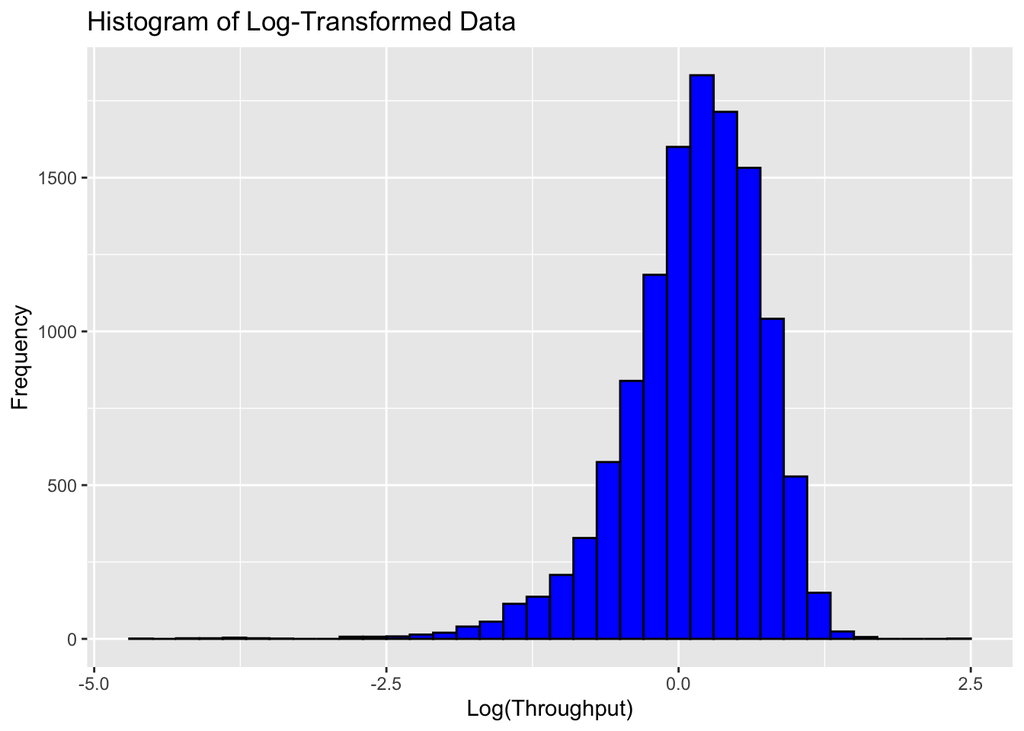

```r
ggplot(tp_poke, aes(x = log(TP))) +
  geom_histogram(binwidth = 0.2, color = "black", fill = "blue") +
  labs(title = "Histogram of Log-Transformed Data", x = "Log(Throughput)", y = "Frequency")
```

```r
tp_model_poke <- brm(TP ~ 1 + (1|participant) + iterationNum + exercise + (IDe * (weight * movement)),
                     tp_poke,
                     family = shifted_lognormal(),
                     iter = 5000,
                     save_pars = save_pars(all = TRUE))
saveRDS(tp_model_poke, file = "brm_model/tp_model_poke.rds")
```

```r
tp_model_poke <- readRDS("brm_model/tp_model_poke.rds")
summary(tp_model_poke)
```

```
 Family: shifted_lognormal
  Links: mu = identity; sigma = identity; ndt = identity
Formula: TP ~ 1 + (1 | participant) + iterationNum + exercise + (IDe * (weight * movement))
   Data: poke_tp (Number of observations: 11978)
  Draws: 4 chains, each with iter = 5000; warmup = 2500; thin = 1;
         total post-warmup draws = 10000

Multilevel Hyperparameters:
~participant (Number of levels: 30)
              Estimate Est.Error l-95% CI u-95% CI Rhat Bulk_ESS Tail_ESS
sd(Intercept)     0.24      0.03     0.19     0.32 1.00     1525     2675

Regression Coefficients:
                           Estimate Est.Error l-95% CI u-95% CI Rhat Bulk_ESS
Intercept                     -0.71      0.07    -0.85    -0.57 1.00     1992
iterationNum                   0.04      0.00     0.03     0.04 1.00     9141
exercise                       0.01      0.01    -0.00     0.02 1.00     1829
IDe                            0.95      0.02     0.90     0.99 1.00     3687
weight                        -0.33      0.04    -0.40    -0.26 1.00     3566
movementWalking               -0.26      0.03    -0.32    -0.19 1.00     3479
weight:movementWalking         0.08      0.05    -0.03     0.18 1.00     3397
IDe:weight                     0.10      0.04     0.02     0.17 1.00     3580
IDe:movementWalking            0.11      0.03     0.05     0.18 1.00     3403
IDe:weight:movementWalking    -0.15      0.05    -0.26    -0.05 1.00     3431
                           Tail_ESS
Intercept                      2691
iterationNum                   5680
exercise                       2737
IDe                            4673
weight                         4861
movementWalking                4220
weight:movementWalking         4734
IDe:weight                     5108
IDe:movementWalking            3780
IDe:weight:movementWalking     4477

Further Distributional Parameters:
      Estimate Est.Error l-95% CI u-95% CI Rhat Bulk_ESS Tail_ESS
sigma     0.39      0.00     0.39     0.40 1.00     7639     5767
ndt       0.00      0.00     0.00     0.00 1.00     4876     3461

Draws were sampled using sampling(NUTS). For each parameter, Bulk_ESS
and Tail_ESS are effective sample size measures, and Rhat is the potential
scale reduction factor on split chains (at convergence, Rhat = 1).
```

**Ray-Casting**

Model for target acquisition (ray-casting)

```r
tp_ray <- ray %>%
  # Step 1: Group by participant, width, distance, and iterationNum, calculate SD of accuracy
  group_by(participant, halfWidth, distance, iterationNum) %>%
  mutate(SD = sd(accuracy, na.rm = TRUE)) %>%
  ungroup() %>%

  # Step 2: Calculate ID_e
  mutate(We = 4.133 * SD,
         IDe = log2((distance / We) + 1)) %>%

  # Step 3: Calculate TP
  mutate(TP = IDe / (MT/1000))
```

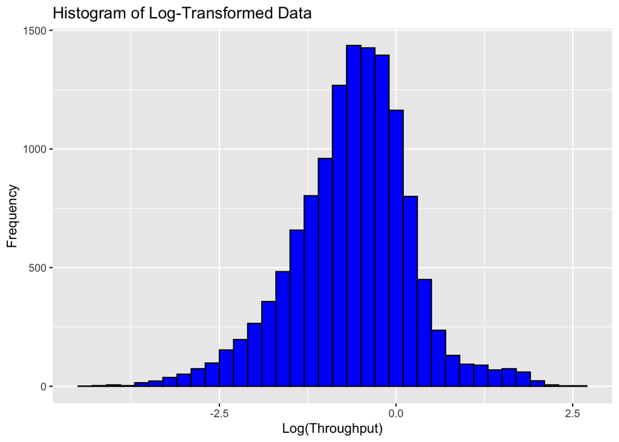

```r
ggplot(tp_ray, aes(x = log(TP))) +
  geom_histogram(binwidth = 0.2, color = "black", fill = "blue") +
  labs(title = "Histogram of Log-Transformed Data", x = "Log(Throughput)", y = "Frequency")
```

```r
tp_model_ray <- brm(TP ~ 1 + (1|participant) + iterationNum + exercise + (IDe * (weight * movement)),
                    tp_ray,
                    family = shifted_lognormal(),
                    iter = 4000,
                    save_pars = save_pars(all = TRUE))
saveRDS(tp_model_ray, file = "brm_model/tp_model_ray.rds")
```

```r
tp_model_ray <- readRDS("brm_model/tp_model_ray.rds")
summary(tp_model_ray)
```

```
 Family: shifted_lognormal
  Links: mu = identity; sigma = identity; ndt = identity
Formula: TP ~ 1 + (1 | participant) + iterationNum + exercise + (IDe * (weight * movement))
   Data: ray_tp (Number of observations: 12908)
  Draws: 4 chains, each with iter = 4000; warmup = 2000; thin = 1;
         total post-warmup draws = 8000

Multilevel Hyperparameters:
~participant (Number of levels: 30)
              Estimate Est.Error l-95% CI u-95% CI Rhat Bulk_ESS Tail_ESS
sd(Intercept)     0.24      0.04     0.18     0.32 1.00     1162     2130

Regression Coefficients:
                           Estimate Est.Error l-95% CI u-95% CI Rhat Bulk_ESS
Intercept                     -1.30      0.08    -1.45    -1.14 1.00     1725
iterationNum                   0.03      0.00     0.02     0.04 1.00     7627
exercise                       0.01      0.01    -0.00     0.02 1.00     1535
IDe                            0.86      0.04     0.79     0.94 1.00     3133
weight                        -0.31      0.06    -0.43    -0.19 1.00     2824
movementWalking               -0.21      0.06    -0.32    -0.10 1.00     2852
weight:movementWalking        -0.16      0.09    -0.33     0.01 1.00     2609
IDe:weight                     0.09      0.06    -0.03     0.20 1.00     2814
IDe:movementWalking           -0.13      0.05    -0.24    -0.03 1.00     2837
IDe:weight:movementWalking     0.06      0.08    -0.10     0.23 1.00     2599
                           Tail_ESS
Intercept                      2712
iterationNum                   5154
exercise                       2379
IDe                            4227
weight                         4103
movementWalking                4137
weight:movementWalking         3935
IDe:weight                     4052
IDe:movementWalking            3974
IDe:weight:movementWalking     4008

Further Distributional Parameters:
      Estimate Est.Error l-95% CI u-95% CI Rhat Bulk_ESS Tail_ESS
sigma     0.71      0.00     0.70     0.72 1.00     7251     5536
ndt       0.00      0.00     0.00     0.00 1.00     4877     3224

Draws were sampled using sampling(NUTS). For each parameter, Bulk_ESS
and Tail_ESS are effective sample size measures, and Rhat is the potential
scale reduction factor on split chains (at convergence, Rhat = 1).
```

**Validation**

Posterior Probability Check

```
Using 10 posterior draws for ppc type 'dens_overlay' by default.
```

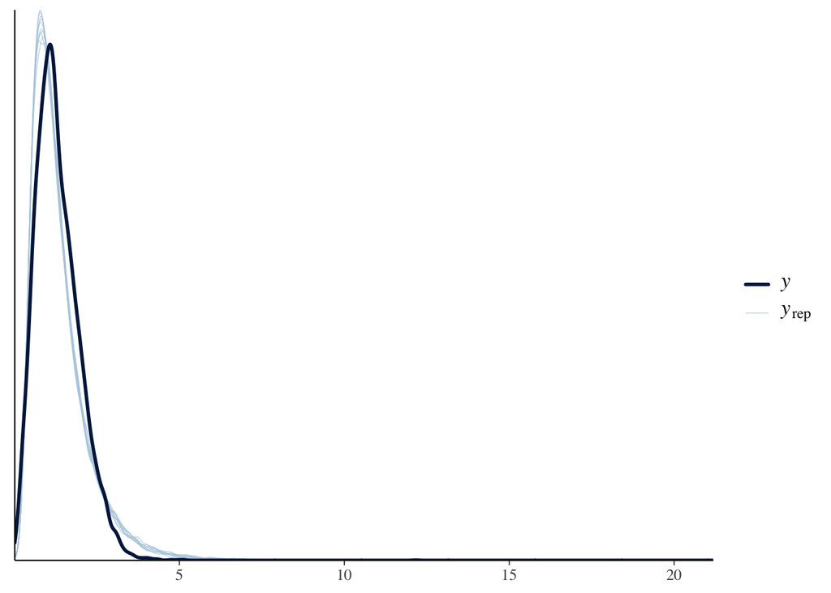

```r
# Target Acquisition (Direct Selection) Throughput Model
pp_check(tp_model_poke)
```

```r
# Target Acquisition (Direct Selection) Throughput Model
post <- as_draws_df(tp_model_poke)
cat("Weight Probability:", as.character(mean(post$b_weight > 0)),
    "Motion Probability:", as.character(mean(post$b_movementWalking > 0)),
    "Weight x Motion Probability:", as.character(mean(post$`b_weight:movementWalking` > 0)))
```

```
Weight Probability: 0 Motion Probability: 0 Weight x Motion Probability: 0.9286
```

```
Using 10 posterior draws for ppc type 'dens_overlay' by default.
```

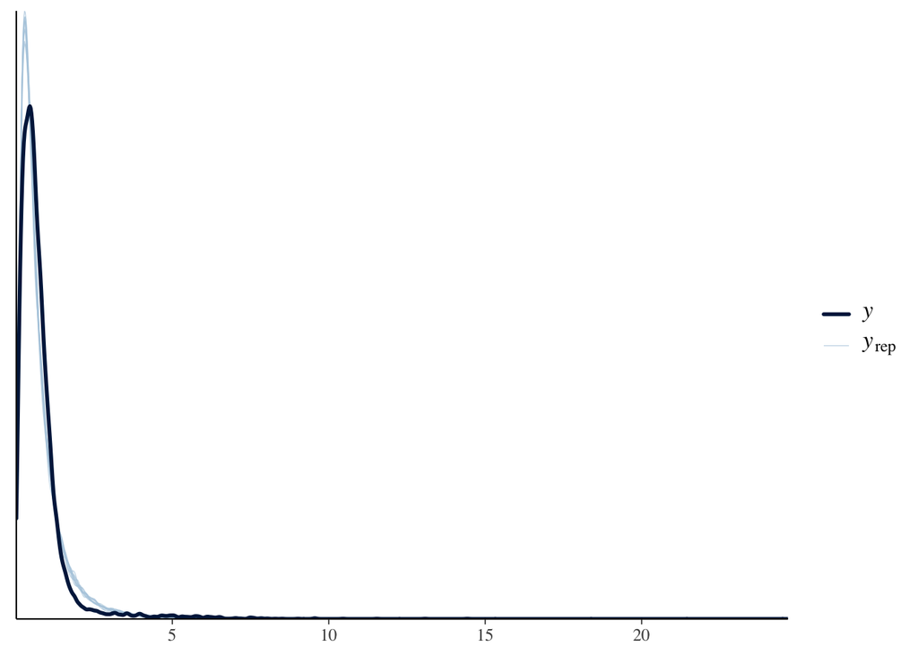

```r
# Target Acquisition (Ray-Casting) Throughput Model
pp_check(tp_model_ray)
```

```r
# Target Acquisition (Ray-Casting) Throughput Model
post <- as_draws_df(tp_model_ray)
cat("Weight Probability:", as.character(mean(post$b_weight > 0)),
    "Motion Probability:", as.character(mean(post$b_movementWalking > 0)),
    "Weight x Motion Probability:", as.character(mean(post$`b_weight:movementWalking` > 0)))
```

```
Weight Probability: 0 Motion Probability: 0.000625 Weight x Motion Probability: 0.03575
```

Bayes Factor

```r
# Target Acquisition (Direct Selection) Throughput without Weight
tp_model_poke_weight <- brm(TP ~ 1 + (1|participant) + iterationNum + exercise + (IDe * movement), poke_tp, family = shifted_lognormal(), iter = 5000, save_pars = save_pars(all = TRUE))
saveRDS(tp_model_poke_weight, file = "brm_model/tp_model_poke_weight.rds")

# Target Acquisition (Direct Selection) Throughput without Motion
tp_model_poke_movement <- brm(TP ~ 1 + (1|participant) + iterationNum + exercise + (IDe * weight), poke_tp, family = shifted_lognormal(), iter = 5000, save_pars = save_pars(all = TRUE))
saveRDS(tp_model_poke_movement, file = "brm_model/tp_model_poke_movement.rds")

# Target Acquisition (Ray-Casting) Throughput without Weight
tp_model_ray_weight <- brm(TP ~ 1 + (1|participant) + iterationNum + exercise + (IDe * movement), ray_tp, family = shifted_lognormal(), iter = 4000, save_pars = save_pars(all = TRUE))
saveRDS(tp_model_ray_weight, file = "brm_model/tp_model_ray_weight.rds")

# Target Acquisition (Ray-Casting) Throughput without Motion
tp_model_ray_movement <- brm(TP ~ 1 + (1|participant) + iterationNum + exercise + (IDe * weight), ray_tp, family = shifted_lognormal(), iter = 4000, save_pars = save_pars(all = TRUE))
saveRDS(tp_model_ray_movement, file = "brm_model/tp_model_ray_movement.rds")
```

```r
tp_model_poke_weight <- readRDS("brm_model/tp_model_poke_weight.rds")
tp_model_poke_movement <- readRDS("brm_model/tp_model_poke_movement.rds")
tp_model_ray_weight <- readRDS("brm_model/tp_model_ray_weight.rds")
tp_model_ray_movement <- readRDS("brm_model/tp_model_ray_movement.rds")

bf_tp_poke_weight <- bayes_factor(tp_model_poke, tp_model_poke_weight)
bf_tp_poke_movement <- bayes_factor(tp_model_poke, tp_model_poke_movement)
bf_tp_ray_weight <- bayes_factor(tp_model_ray, tp_model_ray_weight)
bf_tp_ray_movement <- bayes_factor(tp_model_ray, tp_model_ray_movement)
```

```r
# Target Acquisition (Direct Selection) Throughput without Weight
print(bf_tp_poke_weight)
```

[output not shown]

```r
# Target Acquisition (Direct Selection) Throughput without Motion
print(bf_tp_poke_movement)
```

```
Estimated Bayes factor in favor of tp_model_poke over tp_model_poke_movement: 10076450288795630919747705896559947944442206091627632411215016413870234056804400923970203659054626685561416909858307143207005661931954688229376.00000
```

```r
# Target Acquisition (Ray-Casting) Throughput without Weight
print(bf_tp_ray_weight)
```

```
Estimated Bayes factor in favor of tp_model_ray over tp_model_ray_weight: 354702725003401265719533688488721599702310771690525950822723418612301824.00000
```

```r
# Target Acquisition (Ray-Casting) Throughput without Motion
print(bf_tp_ray_movement)
```

[output not shown]

**Plot**

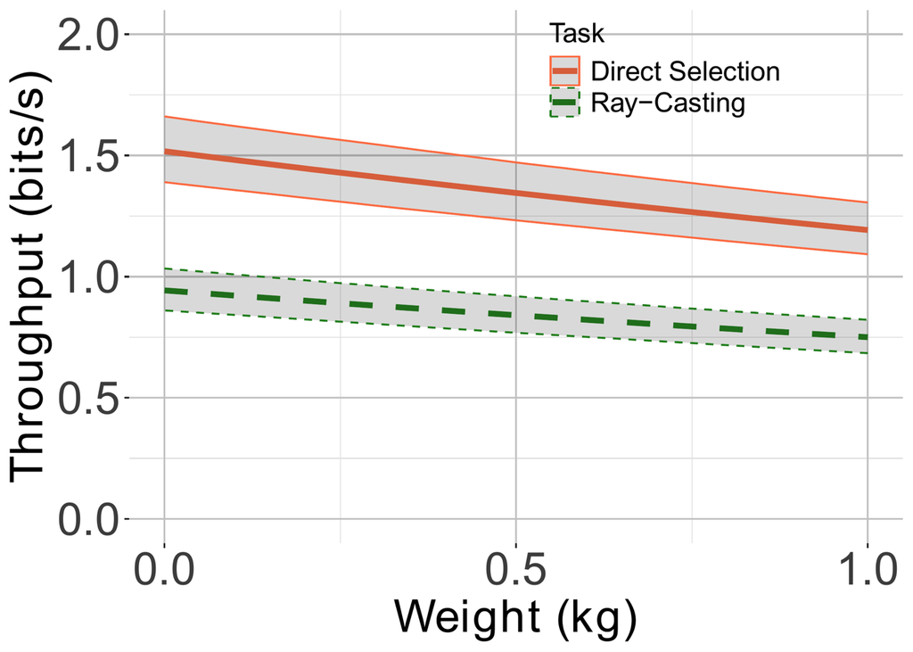

```r
# Effect of Weight on Target Acquisition Throughput
combined_weight_plot
```

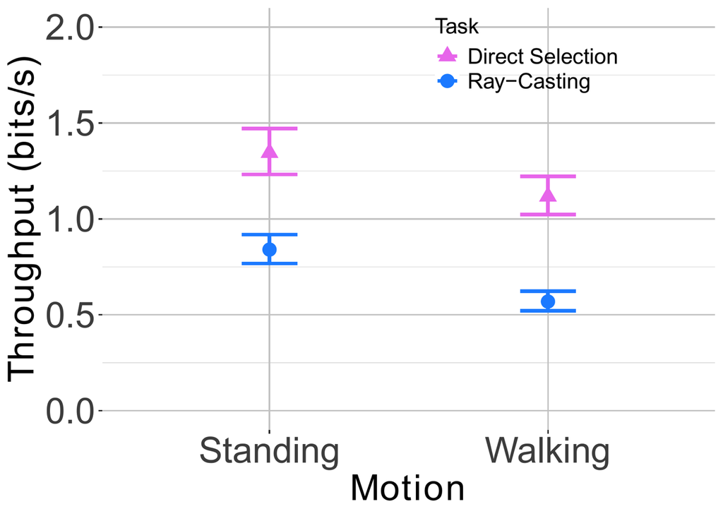

```r
# Effect of Motion on Target Acquisition Throughput
combined_motion_plot
```

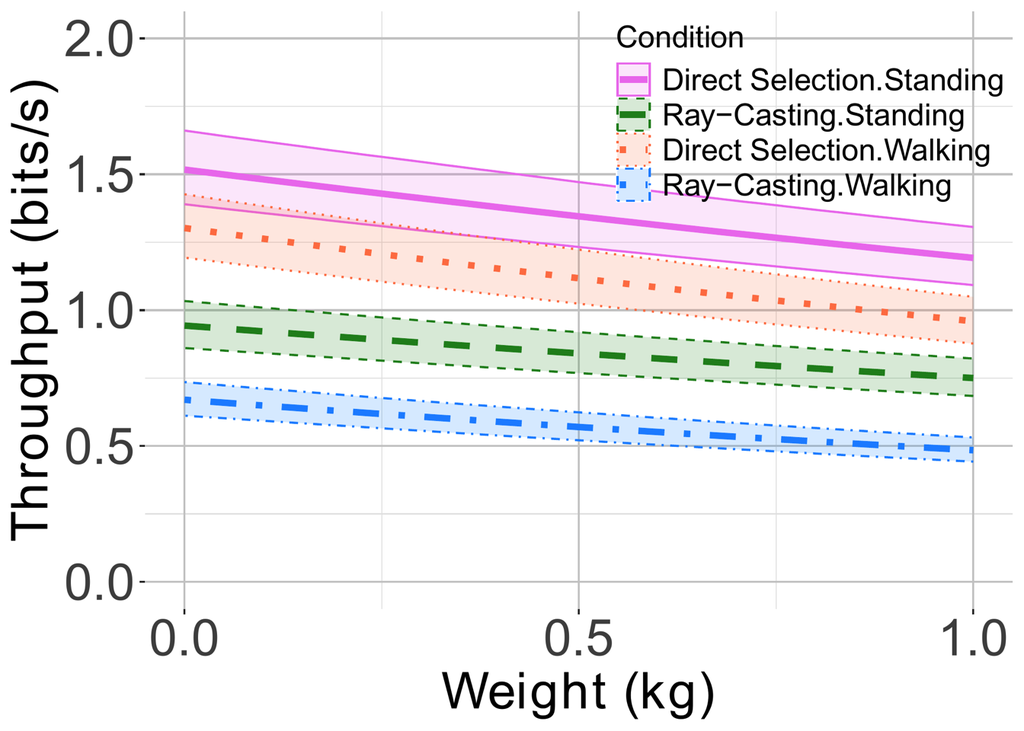

```r
# Interaction Effect of Weight and Motion on Target Acquisition Throughput
combined_interaction_plot
```

# 4 Text Entry Task

This section contains the analysis of text entry task performed in the paper.

**4.1 Text Entry Throughput**

This section presents the text entry throughput models and the corresponding outcomes from the text entry task.

**Model**

```r
text_nozero <- text %>% filter(TP > 0)
```

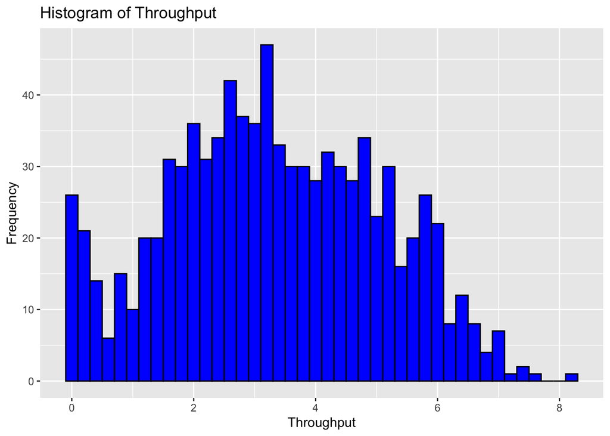

```r
ggplot(text_nozero, aes(x = TP)) +
  geom_histogram(binwidth = 0.2, color = "black", fill = "blue") +
  labs(title = "Histogram of Throughput", x = "Throughput", y = "Frequency")
```

```r
tp_nozero_model <- brm(TP ~ 1 + (1|participant) + iterationNum + exercise + weight * movement,
                       text_nozero,
                       family = gaussian(),
                       iter = 4000,
                       save_pars = save_pars(all = TRUE))
saveRDS(tp_nozero_model, file = "brm_model/tp_nozero_model.rds")
```

```r
tp_nozero_model <- readRDS("brm_model/tp_nozero_model.rds")
summary(tp_nozero_model)
```

```
 Family: gaussian
  Links: mu = identity; sigma = identity
Formula: TP ~ 1 + (1 | participant) + iterationNum + exercise + weight * movement
   Data: text_nozero (Number of observations: 882)
  Draws: 4 chains, each with iter = 4000; warmup = 2000; thin = 1;
         total post-warmup draws = 8000

Multilevel Hyperparameters:
~participant (Number of levels: 30)
              Estimate Est.Error l-95% CI u-95% CI Rhat Bulk_ESS Tail_ESS
sd(Intercept)     0.77      0.11     0.58     1.03 1.00     1506     3217

Regression Coefficients:
                       Estimate Est.Error l-95% CI u-95% CI Rhat Bulk_ESS
Intercept                  4.44      0.24     3.99     4.92 1.00     1206
iterationNum               0.17      0.02     0.13     0.21 1.00     8756
exercise                  -0.00      0.02    -0.04     0.04 1.00     1330
weight                    -0.82      0.12    -1.05    -0.58 1.00     4747
movementWalking           -2.52      0.11    -2.74    -2.31 1.00     4300
weight:movementWalking     0.52      0.17     0.19     0.86 1.00     3974
                       Tail_ESS
Intercept                  2093
iterationNum               5554
exercise                   2366
weight                     5597
movementWalking            5857
weight:movementWalking     5115

Further Distributional Parameters:
      Estimate Est.Error l-95% CI u-95% CI Rhat Bulk_ESS Tail_ESS
sigma     1.05      0.03     1.00     1.10 1.00     9107     6121

Draws were sampled using sampling(NUTS). For each parameter, Bulk_ESS
and Tail_ESS are effective sample size measures, and Rhat is the potential
scale reduction factor on split chains (at convergence, Rhat = 1).
```

**Validation**

Posterior Probability Check

```
Using 10 posterior draws for ppc type 'dens_overlay' by default.
```

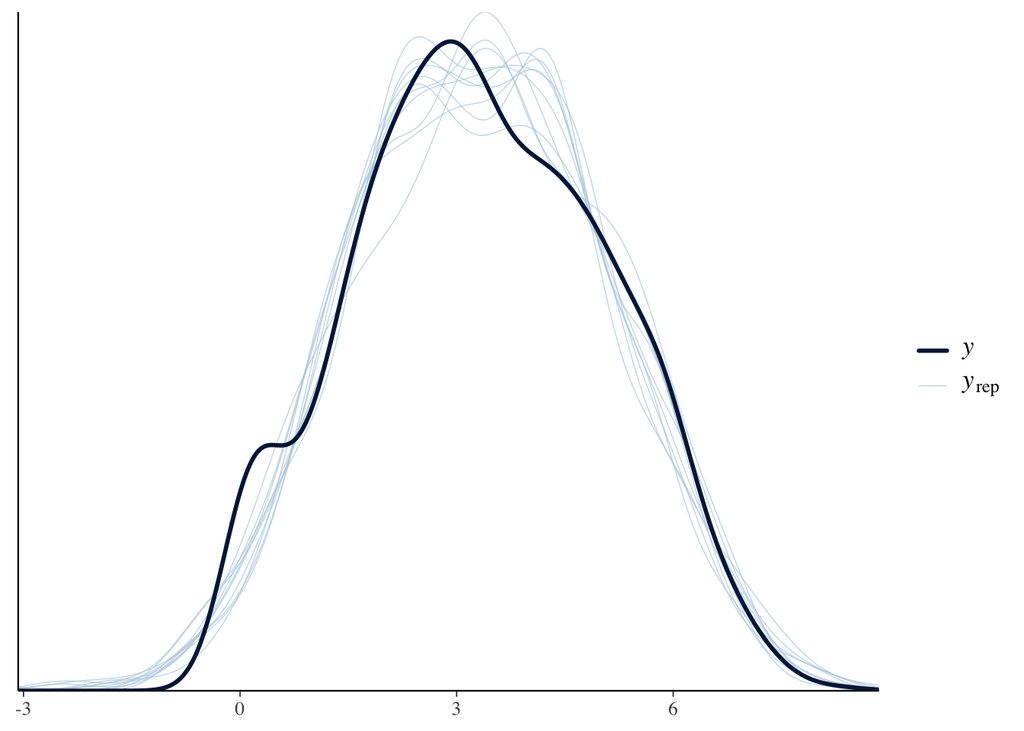

```r
# Text Entry Throughput Model
pp_check(tp_nozero_model)
```

```r
# Text Entry Throughput Model
post <- as_draws_df(tp_nozero_model)
cat("Weight Probability:", as.character(mean(post$b_weight > 0)),
    "Motion Probability:", as.character(mean(post$b_movementWalking > 0)),
    "Weight x Motion Probability:", as.character(mean(post$`b_weight:movementWalking` > 0)))
```

```
Weight Probability: 0 Motion Probability: 0 Weight x Motion Probability: 0.9985
```

Bayes Factor

```r
# Text Entry Throughput without Weight
tp_nozero_model_weight <- brm(TP ~ 1 + (1|participant) + iterationNum + exercise + movement, text_nozero, family = gaussian(), iter = 4000, save_pars = save_pars(all = TRUE))
saveRDS(tp_nozero_model_weight, file = "brm_model/tp_nozero_model_weight.rds")

# Text Entry Throughput without Motion
tp_nozero_model_movement <- brm(TP ~ 1 + (1|participant) + iterationNum + exercise + weight, text_nozero, family = gaussian(), iter = 4000, save_pars = save_pars(all = TRUE))
saveRDS(tp_nozero_model_movement, file = "brm_model/tp_nozero_model_movement.rds")
```

```r
tp_nozero_model_weight <- readRDS("brm_model/tp_nozero_model_weight.rds")
tp_nozero_model_movement <- readRDS("brm_model/tp_nozero_model_movement.rds")

bf_tp_weight <- bayes_factor(tp_nozero_model, tp_nozero_model_weight)
bf_tp_movement <- bayes_factor(tp_nozero_model, tp_nozero_model_movement)
```

```r
# Text Entry Throughput without Weight
print(bf_tp_weight)
```

```
Estimated Bayes factor in favor of tp_nozero_model over tp_nozero_model_weight: 4660427286.16737
```

```r
# Text Entry Throughput without Motion
print(bf_tp_movement)
```

```
Estimated Bayes factor in favor of tp_nozero_model over tp_nozero_model_movement: 32172716177568100452049714312465671137546631882506495229276867284328419644235462520188214626347686245744933880213869909517975375369632804274962432.00000
```

**Plot**

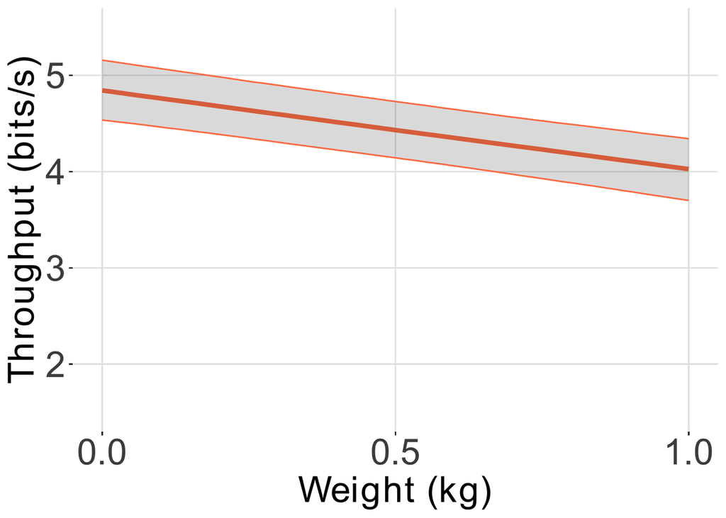

```r
# Effect of Weight on Text Entry Throughput
combined_weight_plot
```

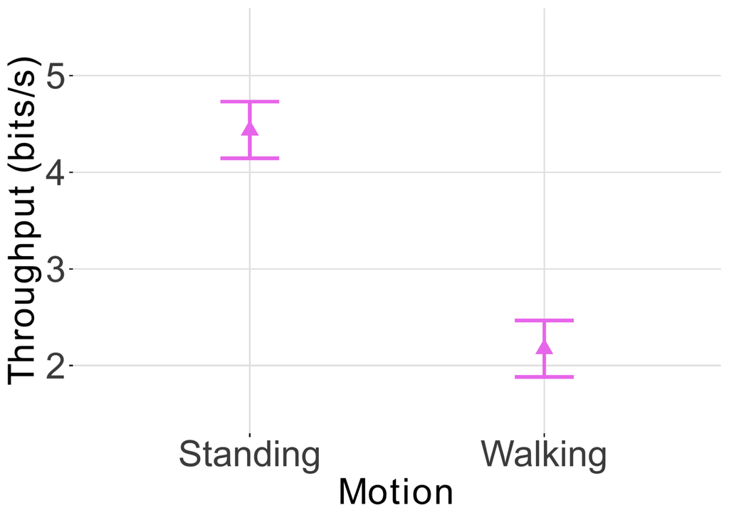

```r
# Effect of Motion on Text Entry Throughput
combined_motion_plot
```

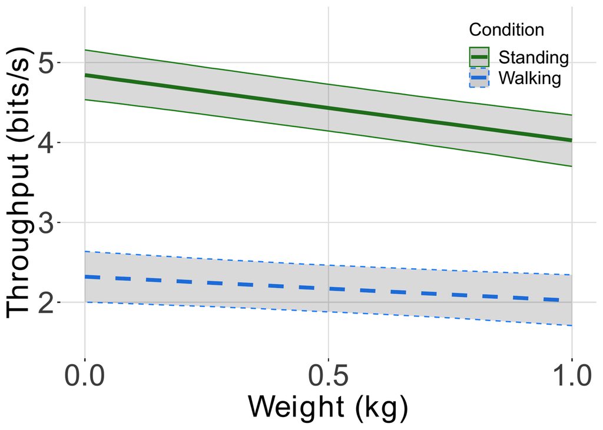

```r
# Interaction Effect of Weight and Motion on Text Entry Throughput
combined_interaction_plot
```

**4.2 Error Rate**

**Uncorrected Error Rate**

Model for uncorrected error rate

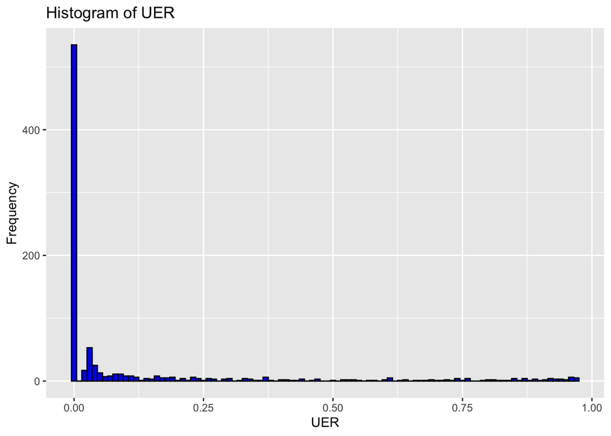

```r
ggplot(text_nozero, aes(x = UER)) +
  geom_histogram(binwidth = 0.01, color = "black", fill = "blue") +
  labs(title = "Histogram of UER", x = "UER", y = "Frequency")
```